# Essential Statistics for Data Science: The Pareto Distribution

## Overview

### What Do I Need to Know to Do Data Science?

#### The Venn Diagram of Data Science Skills

If this isn't your first course on data science, you might have come accross the following Venn diagram:

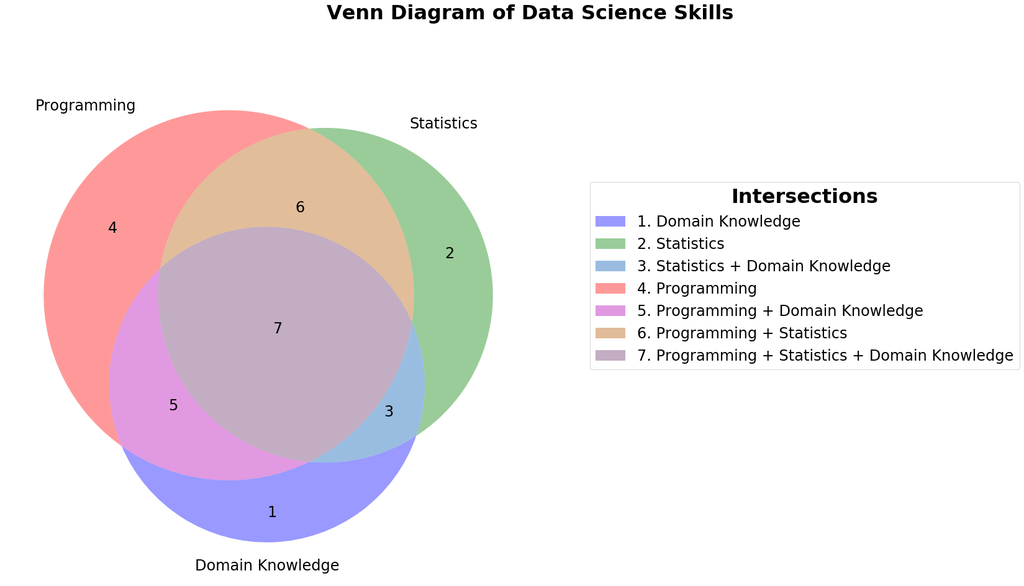

```python
# include matplotlib graphs in your rendered notebook
%matplotlib inline


import matplotlib.pyplot as plt
from matplotlib_venn import venn3

def set_labels_font_size(diagram, size):
    for text in diagram.set_labels:
        text.set_fontsize(size)

def set_subsets_font_size(diagram, size):
    for text in diagram.subset_labels:
        text.set_fontsize(24)

def create_legend_box(diagram, intersection_labels, font_size, title_font_size):
    handles = [diagram.get_patch_by_id(i) for i in subsets]
    axes = plt.gca()
    legend = axes.legend(handles=handles,
                         labels=intersection_labels,
                         title="Intersections",
                         fontsize=font_size,
                         bbox_to_anchor=(1.1, 0.8))
    legend.get_title().set_fontweight('bold')
    legend.get_title().set_fontsize(title_font_size)

def venn_diagram(title, subsets, set_labels, intersection_labels,
                 figsize=(25, 15), font_size=24, title_font_size=32):
    figure = plt.figure(figsize=figsize)
    plt.title(title, fontweight="bold",  fontsize=title_font_size, x=1.0, y=1.1)

    diagram = venn3(subsets = subsets, set_labels = set_labels)
    set_labels_font_size(diagram, font_size)
    set_subsets_font_size(diagram, font_size)
    create_legend_box(diagram, intersection_labels, font_size, title_font_size)

    return figure


subsets = {'001':1, '010':2, '011':3, '100':4, '101':5, '110':6, '111':7}
set_labels = ('Programming', 'Statistics', 'Domain Knowledge')
intersection_labels = ['1. Domain Knowledge', '2. Statistics',
                       '3. Statistics + Domain Knowledge', '4. Programming',
                       '5. Programming + Domain Knowledge',
                       '6. Programming + Statistics',
                       '7. Programming + Statistics + Domain Knowledge']

figure = venn_diagram('Venn Diagram of Data Science Skills', subsets, set_labels, intersection_labels)
figure.savefig('data-science-venn-diagram1', bbox_inches='tight')
plt.show()
```

Don't mind so much about the code at this moment. This lesson is about data science and statistics in general and the Pareto distribution in particular. Let me know If you would like to learn more about plotting in Python though, as I would be happy to create a lesson on the subject. Now back to business...

Each colored circle represents one of the fundamental skills that should be part of any data scientist's toolbox:

- **Programming Skills:** You're capable of writing code in some programming language that supports statistics, data visualization and machine learning. For example, Python or R.
- **Statistics:** You understand at least some fundamental concepts from statistics, such as common statistical distributions, regression models, probabilistic inference, machine learning, etc.
- **Domain Knowledge:** You understand the knowledge domain of the data you need to work with in sufficient depth (medicine, advertising, social sciences, etc).

The numbers in the diagram represents different intersections between the three skills. Obviously, all of them need to overlap to produce a competent well-rounded data scientist (intersection 7).

#### Statistics IS NOT Intuitive

Lack of domain knowledge can often be managed with the help of domain experts. Lack of programming skills can be managed with the help of engineers. Knowledge of statistics on the other hand is a critical skill: It's very easy to interpret statistical results incorrectly. Here's an example:

The following are admission figures from the University of California, Berkeley for the fall of 1973:

| Applicants | Total Admitted | Percentage Admitted |
| --- | --- | --- |
| Men | 8442 | 44% |
| Women | 4321 | 35% |

They showed that men applying were more likely than women to be admitted, and the large difference makes unlikely that it's due to chance. Gender bias?

When examining individual departments, it appeared that the majority of the departments were significantly more biased against men rather:

| Department | Men Total | Men Percentage | Women Total | Women Percentage |
| --- | --- | --- | --- | --- |
| A | 825 | 62% | 108 | 82% |
| B | 560 | 63% | 25 | 68% |
| C | 325 | 37% | 593 | 34% |
| D | 417 | 33% | 375 | 35% |
| E | 191 | 28% | 393 | 24% |
| F | 373 | 6% | 341 | 7% |

Gender bias against men then? Turned out not to be the case: This [research paper by Bickel et. all](http://homepage.stat.uiowa.edu/~mbognar/1030/Bickel-Berkeley.pdf) concluded that majority of women applied to more competitive departments with low rates of admission, whereas the majority of men applied to less-competitive departments with high rates of admission.

This type of statistical phenomena, where a trend appears in groups of data but disappears (or reverses) when these groups are combined is a common pattern in data and it's named ["The Simpson's Paradox"](https://en.wikipedia.org/wiki/Simpson%27s_paradox).

Statistics IS NOT intuitive at all! It needs to be learned. You won't be able to wing it...

A classic book on the subject of misinterpreting or obfuscating statistics results is "How to Lie with Statistics":

[figure not shown]

You should be aware that is even easier to lie to yourself than is to lie to others! It doesn't need to be maliciously intentional!

## The Pareto Distribution

A data scientist needs to know at least the most common statistics distributions. I'm starting with one which I believe is fairly neglected in statistics courses. I know that I haven't seen it in ANY of the statistics and data analytics courses I took.

As a matter of fact, I was introduced to Pareto distributions by Tim Ferriss' book on productivity and time management: "The 4-hour Workweek" (or more specfically to the "80-20 rule" or "Pareto principle", which we will discuss later on).

Further research showed me that this distribution is indeed more widely known in business and management circles.

That's no coincidence, given that the Pareto distribution was originally applied to describe the distribution of wealth in a society. In fact, it also applies to many phenomena in the fields of economics and productivity.

## What a Pareto Distribution Looks Like?

### The Power Function

This distribution follows a "power-law", which simply means that the function's output is a power of the input:

$F(x) = b \cdot x^a$

where:

- $b$ is a constant (just a number).
- $a$ is a constant (just a number).
- x is the input.
- F(x) is the output.

Here's the power-law function as a Python function:

```python
import numpy as np

def f(x, b, a):
    return b * (x ** a)

x = np.linspace(1.0, 200.0, 10000, endpoint=False)
y = [f(x_i, b=1.0, a=-2.0) for x_i in x]
```

We are setting "x" with 10,000 data points uniformily distributed in the interval interval [1.0, 200.0]. "y" is generated by applying the power-law function "f" over each data point in "x".

But a picture is worth more than a 1,000 words, so let's plot the data points:

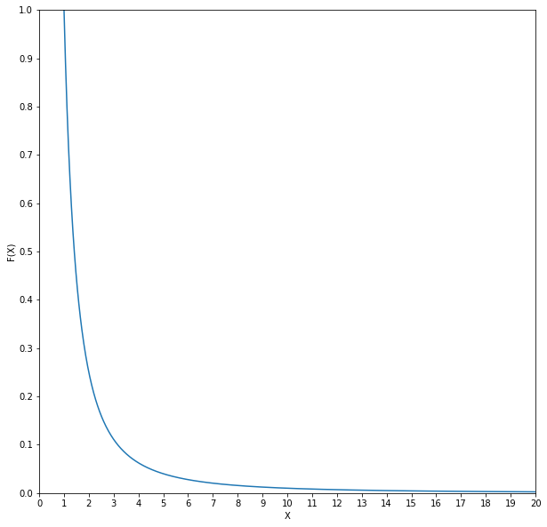

```python
import matplotlib.pyplot as plt

def set_plot_ticks(max_x, max_y, x_step, y_step):
    if x_step is not None: plt.xticks(np.arange(0, max_x + x_step, step=x_step))
    if y_step is not None: plt.yticks(np.arange(0, max_y + y_step, step=y_step))

def set_plot_axis(max_x, max_y, x_step, y_step):
    plt.ylabel('F(X)')
    plt.xlabel('X')
    plt.xlim(0, max_x)
    plt.ylim(0, max_y)
    set_plot_ticks(max_x, max_y, x_step, y_step)

def line_plot(x, y, max_x = None, x_step = None, max_y = None, y_step = None, figsize=(10, 10)):
    if max_x is None: max_x = max(x)
    if max_y is None: max_y = max(y)

    figure = plt.figure(figsize=figsize)
    plt.plot(x, y)
    set_plot_axis(max_x, max_y, x_step, y_step)

    return figure

figure = line_plot(x, y, max_x = 20, x_step = 1, y_step=0.1)
figure.savefig('power-decay-function1', bbox_inches='tight')
plt.show()
```

Again, don't mind so much about the ploting code at this moment.

Note that $a$ could be positive. Let's make $a = 2.0$ and plot the data points:

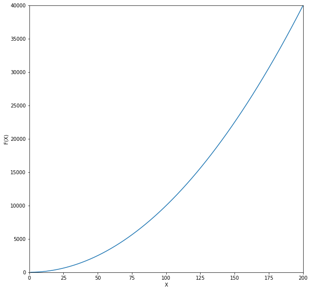

```python
y = [f(x_i, b=1.0, a=2.0) for x_i in x]

figure = line_plot(x, y)
figure.savefig('power-growth-function1')
plt.show()
```

### The Pareto Probablity Density Function

We get the probability density function for a Pareto distribution by setting specific values of "a" and "b". The power-law function for a Pareto distribution is the following:

$F(x) = (\alpha \cdot {x_m}^\alpha) \cdot {x^{-(\alpha + 1)}}$

Note that this is not different from our generic power-law function: The Pareto probability density function is only a special case where $b = \alpha \cdot {m_x}^\alpha$ and $a = -(\alpha + 1)$.

The parameters $\alpha$ and $m_x$ represent the following following properties of the Pareto distribution:

- $x_m$ is the lower bound of the data (the lowest value of the input $x$).
- $\alpha$ is the shape parameter (how fast the function decays or grows).

Let's create a visualization of the Pareto probability density function. The following function not only plots the data points, but also computes the area under the curve:

```python
from scipy.integrate import simps

def line_plot_with_area(x, y, max_x=None, x_step = None, max_y=None, y_step = None, figsize=(10, 10)):
    figure = line_plot(x, y, max_x, x_step, max_y, y_step, figsize)
    if max_y is None: max_y = max(y)
    area = np.round(simps(y, x), decimals=2)
    plt.fill_between(x, 0, y)
    plt.text(0.5 * (min(x) + max_x), 0.5 * (min(y) + max_y),
             "area = %.1f" % area, horizontalalignment='center', fontsize=20)
    return figure
```

Let's build a power-law function with $x_m = 1$ and $\alpha = 1$, generate and plot the data points:

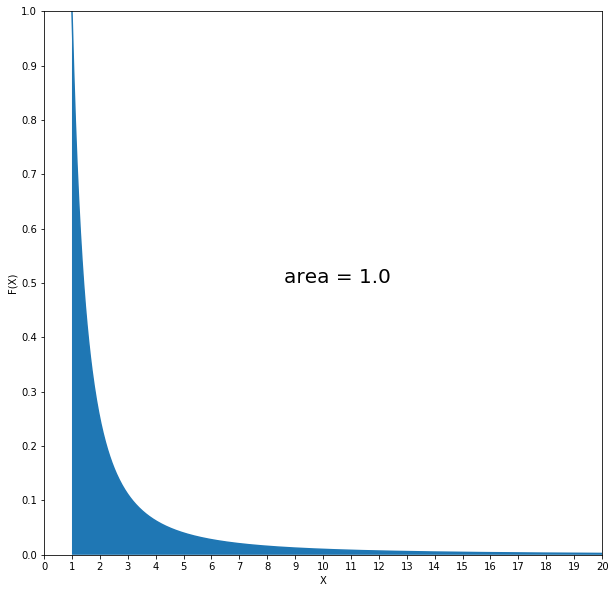

```python
x_m = 1
alpha = 1

y = [f(x_i, b=(alpha * (x_m ** alpha)), a=-(alpha + 1)) for x_i in x]
figure = line_plot_with_area(x, y, max_x = 20, x_step = 1, y_step=0.1)
figure.savefig('pareto-pdf1')
plt.show()
```

```python
def f(x, b, a):
    return b * (x ** a)


x = np.linspace(1.0, 200.0, 10000, endpoint=False)
y = [f(x_i, b=(alpha * (x_m ** alpha)), a=-(alpha + 1)) for x_i in x]
```

Note that the function is defined from $x = 1$ to infinity. In our example, $x$ goes from 1.0 to 200.0 though, so the area we are calculating is an approximation. Still, given that the function decreases fast, we get pretty darn close to one when calculating the area under the curve from $x = 1.0$ to $x = 200.0$ only!

An important fact is that this function describes a probability density, thus function parameters have been defined in such a way that the area under the curve is equal to 1.0.

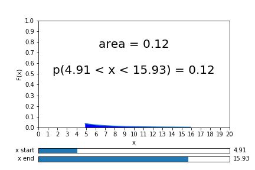

```
0
```

```python
%matplotlib notebook

import pylab as pl
from matplotlib.widgets import Slider
import numpy as np


def set_axis(ax):
    ax.set_ylim(0.0, 1.0)
    ax.set_xlim(0, 20.0)
    pl.xlabel('x')
    pl.ylabel('F(x)')
    pl.xticks(np.arange(0, 21, step=1))
    pl.yticks(np.arange(0, 1.1, step=0.1))

def create_sliders():
    ax_x_end = pl.axes([0.15, 0.05, 0.75, 0.03])
    ax_x_start = pl.axes([0.15, 0.1, 0.75, 0.03])
    slider_x_end = Slider(ax_x_end, 'x end', 1.0, 20.0, valinit=20.0)
    slider_x_start = Slider(ax_x_start, 'x start', 1.0, 20.0, valinit=1.0)
    return (slider_x_start, slider_x_end)

def update_line(x, y):
    line.set_xdata(x)
    line.set_ydata(y)

def update_area(x, y, x_start, x_end):
    ax.collections.clear()
    ax.fill_between(x, 0, y, facecolor='b')
    area = np.round(simps(y, x), decimals=2)
    text_area.set_text("area = %.2f\n\np(%.2f < x < %.2f) = %.2f" % (area, x_start, x_end, area))

def create_x_and_y(x_start, x_end):
    x = np.linspace(x_start, x_end, 10000, endpoint=False)
    y = [f(x_i, b=(alpha * (x_m ** alpha)), a=-(alpha + 1)) for x_i in x]
    return (x, y)

def update(val):
    x_end = slider_x_end.val
    x_start = slider_x_start.val
    if x_end > x_start:
        (x, y) = create_x_and_y(x_start, x_end)
        update_line(x, y)
        update_area(x, y, x_start, x_end)
        pl.draw()


ax = pl.subplot(111)
set_axis(ax)
pl.subplots_adjust(left=0.15, bottom=0.25)

(x_start, x_end) = (1.0, 20.0)
(x, y) = create_x_and_y(x_start, x_end)
line, = pl.plot(x, y)
text_area = ax.text(10.0, 0.5, "", horizontalalignment='center', fontsize=20)

update_area(x, y, 1.0, 20.0)

(slider_x_start, slider_x_end) = create_sliders()
slider_x_end.on_changed(update)
slider_x_start.on_changed(update)
```

You might recall that for a continuous variable x, the probability that x is inside an interval is equal to the area under the curve inside the interval.

The interactive plot above exemplifies that. Just click on the sliders below to define different intervals. The plot will be instantly updated with the correspondent area and probability for the interval, i.e., what's the probability that `x` is inside the correspondent interval.

The area under the whole curve, which represents the probability that x is equal to any possible value, needs to be one. That's the same as saying that "the probability of flipping a coin and getting either head or tails is one.".

### The Statistical Mechanics of Money

You can even simulate it's occurrance. In the scientific paper ["Statistical mechanics of money"](http://physics.umd.edu/~yakovenk/econophysics/animation.html), Dragulescu and Yakovenko created a simulation of money transactions.

In this simulation, 5,000 autonomous agents start with exactly the same amount of money. The simulation kicks off and random pairs of agents exchange random amounts of money among themselves. If a agent runs out of money, it's kicked out of the simulation:

```python
from IPython.display import HTML

HTML('<iframe width="800" height="400" src="https://www.youtube.com/embed/oE5Wl4G9kcA?rel=0&amp;controls=1&amp;showinfo=0" frameborder="0" allowfullscreen></iframe>')
```

[video not shown]

Note that, eventually the simulation reaches a point of equilibrium, with the distribution roughly following the shape of a power-law function.

That might be counter-intuitive for you, depending on your ideology. We start from a state of "fairness" (all agents start with the same amount of money) and end up in a state of unfairness (the majority of money concentrated in the hands of a few agents). Note also that these agents are not malicious savy businessman: They execute transactions at random and still the point of equilibrium isn't an state where the money is uniformly distributed! They have exactly the same "negotiation skills", nothing special about any of them!

## The Pareto Principle

The Pareto principle simply states the following:

> “~80% of the effects come from ~20% of the causes.

Pareto first noticed that about 80% of Italy's land was owned by 20% of the population. But the principle holds in a global scale: The 1992 United Nations Development Program Report showed that distribution of global income is very uneven, with the richest 20% of the world's population controlling 82.7% of the world's income.

### Examples of the Pareto Principle

The principle does not only apply to economics though. Here are some other real-life examples:

- Microsoft noted that by fixing the top 20% of the most-reported bugs, 80% of the related errors and crashes in a given software would be eliminated.
- In load testing for web sites is common practice to estimate that 80% of the traffic will occur during a particular 20% of the total time period.
- In baseball to determine a player's overall importance to a team: "15% of the all the players last year produced 85% of the total wins with the other 85% of the players creating 15% of the wins.
- The Dunedin Study has found that 80% of crimes are committed by 20% of criminals.

### Another Example, The Causes of Holodomor

Here's an example of the Pareto Principle which I thought to be deserving of its own section.

You might be acquainted with [Holomor](https://en.wikipedia.org/wiki/Causes_of_the_Holodomor) from history class. Holomor was a famine that ravaged the Soviet Ukraine in the 1930's. In his efforts to reshape Soviet society and eliminate inequality, [Joseph Stalin](https://en.wikipedia.org/wiki/Joseph_Stalin) ordered arrests, deportations, and executions of better-off peasants and their families. They were labeled "Kulaks" and declared enemies of the state.

Unfortunately, the Soviet state wasn't aware of the Pareto distribution, which not only applies to the distribution of wealth, but also to the distribution of productivity: These "richer peasants", the Kulaks, not only concentrated wealth, but productivity as well. The Kulaks were responsible for over 80% of the food production. Their elimination caused this terrible tragedy!

### From Where the Pareto Principle Comes From?

The Pareto principle, also known as the 80-20 rule comes from assuming a particular value for the shape parameter:

$\alpha = log4(5) = \frac{log(5)}{log(4)}$, which is approximately equal to $1.161$.

Let's generate and plot the data points for this particular case:

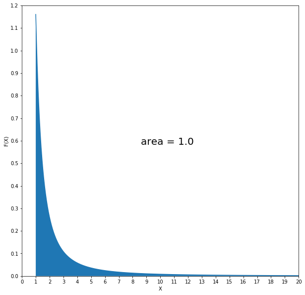

```python
%matplotlib inline

alpha = np.log(5) / np.log(4)

y = [f(x_i, b=(alpha * (x_m ** alpha)), a=-(alpha + 1)) for x_i in x]
figure = line_plot_with_area(x, y, max_x = 20, x_step = 1, y_step=0.1)
figure.savefig('pareto-principle-pdf1')
plt.show()
```

Not much of a difference from our previous plot. In the next plot we will make the difference more evident.

The Pareto principle states that 80% of the output can be explained by 20% of the input. Regarding specifically the probability density function, that means that 20% of interval explains 80% of the total probability (that is, the area under the curve in the interval is equal to 0.8). The remaining 80% of the interval therefore explains the remaining 20% percent of the probability (the area under the curve in the interval is equal to 0.2).

Around $x = 16$, the function becomes very small, so let's take the interval from $x = 1$ to $x = 16$ (length equal to 15) to be 100% of the interval. That's somewhat arbritary so the calculations become easier.

This makes the interval from $x = 1$ to $x = 4$ (length equal to 3, which is equal to 20% of 15) our 20% interval. If we calculate the area under the curve:

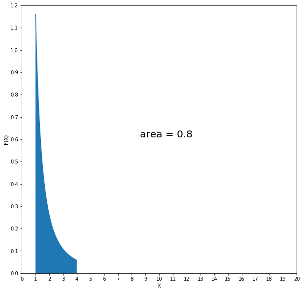

```python
x = np.linspace(start=1.0, stop=4, num=100000, endpoint=False)
y = [f(x_i, b=(alpha * (x_m ** alpha)), a=-(alpha + 1)) for x_i in x]

figure = line_plot_with_area(x, y, max_x = 20, x_step = 1, y_step=0.1)
figure.savefig('pareto-principle-pdf-20-percent-interval-1')
plt.show()
```

20% of the interval accounts for 0.8 or 80% of the total probability. The remaining of the interval correspond to the remaining 80%. If we calculate the area under the curve:

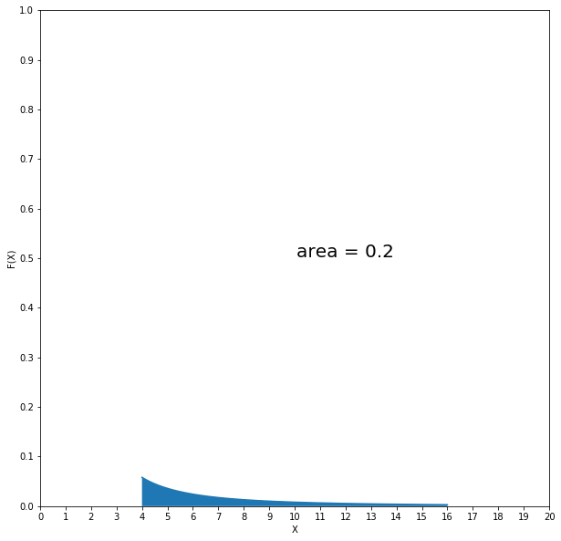

```python
x = np.linspace(start=4, stop=16, num=100000, endpoint=False)
y = [f(x_i, b=(alpha * (x_m ** alpha)), a=-(alpha + 1)) for x_i in x]

figure = line_plot_with_area(x, y, max_x=20, max_y=1, x_step = 1, y_step=0.1)
figure.savefig('pareto-principle-pdf-80-percent-interval-1')
plt.show()
```

The remaining 80% of the interval accounts for only 0.2 or 20% of the total probability!

Would be nice to see the two areas in a single plot. The following function breaks the interval in two and plot their correspondent areas:

```python
def plot_area(x, y, min_x, max_x, min_y, max_y, area, text_position, color):
    plt.fill_between(x, 0, y)
    plt.text(text_position * (min_x + max_x), 0.5 * (min_y + max_y),
             "area = %.1f" % area, horizontalalignment='center', fontsize=20, color=color)

def line_plot_with_split_area(x, y, x_split, max_x=None, x_step = None, max_y=None, y_step = None):
    figure = line_plot(x, y, max_x, x_step, max_y, y_step)
    if max_y is None: max_y = max(y)
    min_x = min(x)
    min_y = min(y)

    split_index = np.where(x == x_split)[0] + 1
    x1, x2 = np.split(x, split_index)
    y1, y2 = np.split(y, split_index)
    area1 = np.round(simps(y1, x1), decimals=2)
    area2 = np.round(simps(y2, x2), decimals=2)

    plot_area(x1, y1, min_x, max_x, min_y, max_y, area1, 0.25, 'blue')
    plot_area(x2, y2, min_x, max_x, min_y, max_y, area2, 0.75, 'red')

    return figure
```

Let's put the two areas together in a single plot covering the whole interval:

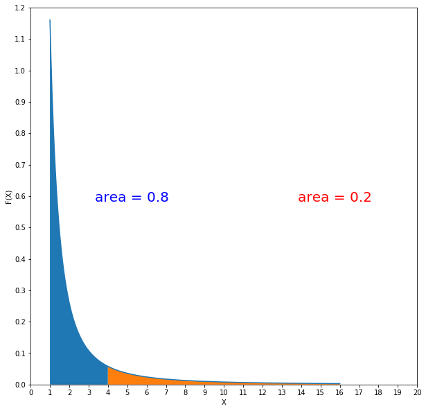

```python
x = np.linspace(start=1, stop=16, num=300000, endpoint=False)
y = [f(x_i, b=(alpha * (x_m ** alpha)), a=-(alpha + 1)) for x_i in x]

figure = line_plot_with_split_area(x, y, x_split = 4, max_x = 20, x_step = 1, y_step=0.1)
figure.savefig('pareto-principle-pdf-20-and-80-percent-interval-1')
plt.show()
```

## Pareto Analysis Step by Step

Here we are going to look at some real-life data that follows a Pareto distribution. The data has been downloaded from the [Consumer Financial Protection Bureau](https://www.consumerfinance.gov/data-research/consumer-complaints/search/). This data is constantly updated, so the data used in this notebook (`*.csv` file) is a snapshot from a particular date.

We are going to use [Pandas](https://pandas.pydata.org/) to ETL (extract, transform and load) our data. Don't worry if you are not familiar with the term. We are going to go through it in the following steps.

Let's first import Pandas and extract your data from the `*.csv` file:

```python
import pandas as pd

complaints = pd.read_csv('complaints-2018-07-12_05_32.zip', compression='zip')
```

Let's see how many records we have:

```python
complaints.shape
```

```
(259436, 18)
```

That's about one quarter of a million records, each one with 18 columns. Let's take a look at a small sample from the data:

```python
complaints[:10]
```

|  | Date received | Product | Sub-product | Issue | Sub-issue | Consumer complaint narrative | Company public response | Company | State | ZIP code | Tags | Consumer consent provided? | Submitted via | Date sent to company | Company response to consumer | Timely response? | Consumer disputed? | Complaint ID |
| --- | --- | --- | --- | --- | --- | --- | --- | --- | --- | --- | --- | --- | --- | --- | --- | --- | --- | --- |
| 0 | 01/30/18 | Money transfer, virtual currency, or money ser... | Virtual currency | Other transaction problem | NaN | On XX/XX/2017, I purchased XXXX ETH ( Ethereum... | NaN | Coinbase, Inc. | WA | 981XX | NaN | Consent provided | Web | 01/30/18 | Closed with explanation | Yes | NaN | 2797189 |
| 1 | 03/05/18 | Credit reporting, credit repair services, or o... | Credit reporting | Improper use of your report | Reporting company used your report improperly | Today I was contacted by appointment with XXXX... | Company has responded to the consumer and the ... | BANK OF AMERICA, NATIONAL ASSOCIATION | FL | 334XX | NaN | Consent provided | Web | 03/12/18 | Closed with explanation | Yes | NaN | 2833270 |
| 2 | 03/14/18 | Credit reporting, credit repair services, or o... | Credit reporting | Incorrect information on your report | Public record information inaccurate | I have disputed the existence of the inaccurat... | Company has responded to the consumer and the ... | Experian Information Solutions Inc. | IL | 606XX | NaN | Consent provided | Web | 03/14/18 | Closed with non-monetary relief | Yes | NaN | 2843768 |
| 3 | 01/30/18 | Credit reporting, credit repair services, or o... | Credit reporting | Incorrect information on your report | Account status incorrect | NaN | NaN | HYUNDAI CAPITAL AMERICA | CA | 90045 | NaN | Consent not provided | Web | 01/30/18 | Closed with non-monetary relief | Yes | NaN | 2798225 |
| 4 | 01/30/18 | Checking or savings account | Checking account | Opening an account | Account opened as a result of fraud | NaN | NaN | FIFTH THIRD FINANCIAL CORPORATION | OH | 44105 | NaN | Consent not provided | Web | 01/30/18 | Closed with non-monetary relief | Yes | NaN | 2797458 |
| 5 | 03/16/18 | Credit reporting, credit repair services, or o... | Credit reporting | Unable to get your credit report or credit score | Problem getting your free annual credit report | I have tried to get my free annual credit repo... | Company has responded to the consumer and the ... | TRANSUNION INTERMEDIATE HOLDINGS, INC. | PR | 009XX | NaN | Consent provided | Web | 03/16/18 | Closed with non-monetary relief | Yes | NaN | 2845582 |
| 6 | 03/10/18 | Credit reporting, credit repair services, or o... | Credit reporting | Incorrect information on your report | Information belongs to someone else | I was denied a loan and received a copy of my ... | Company has responded to the consumer and the ... | Experian Information Solutions Inc. | CA | 925XX | NaN | Consent provided | Web | 03/10/18 | Closed with non-monetary relief | Yes | NaN | 2839027 |
| 7 | 02/09/18 | Debt collection | Other debt | Attempts to collect debt not owed | Debt is not yours | Ic systems is reporting and attempting a debt ... | Company has responded to the consumer and the ... | I.C. System, Inc. | IL | 611XX | Servicemember | Consent provided | Web | 02/14/18 | Closed with explanation | Yes | NaN | 2808086 |
| 8 | 02/09/18 | Credit reporting, credit repair services, or o... | Credit reporting | Incorrect information on your report | Personal information incorrect | I have had my credit information with Experian... | Company has responded to the consumer and the ... | Experian Information Solutions Inc. | TX | 752XX | NaN | Consent provided | Web | 02/09/18 | Closed with non-monetary relief | Yes | NaN | 2808563 |
| 9 | 03/07/18 | Credit reporting, credit repair services, or o... | Credit reporting | Problem with a credit reporting company's inve... | Their investigation did not fix an error on yo... | I submitted Numerous request to TransUnion and... | Company has responded to the consumer and the ... | TRANSUNION INTERMEDIATE HOLDINGS, INC. | TX | 753XX | Servicemember | Consent provided | Web | 03/07/18 | Closed with explanation | Yes | NaN | 2835464 |

Further analysis show that the column "Issue" is particurly interesting for our purposes. Also, "Issue" is comprised of a limited number of short name categories that repeat over and over:

```python
pd.set_option('display.max_colwidth', -1)

complaints[['Issue']].drop_duplicates()[:6]
```

|  | Issue |
| --- | --- |
| 0 | Other transaction problem |
| 1 | Improper use of your report |
| 2 | Incorrect information on your report |
| 4 | Opening an account |
| 5 | Unable to get your credit report or credit score |
| 7 | Attempts to collect debt not owed |

Setting the option "display.max_colwidth" to -1 prevents the value from being truncated on display.

Let's list all the available columns:

```python
complaints.dtypes
```

```
Date received                   object
Product                         object
Sub-product                     object
Issue                           object
Sub-issue                       object
Consumer complaint narrative    object
Company public response         object
Company                         object
State                           object
ZIP code                        object
Tags                            object
Consumer consent provided?      object
Submitted via                   object
Date sent to company            object
Company response to consumer    object
Timely response?                object
Consumer disputed?              float64
Complaint ID                    int64
dtype: object
```

Let's only take the data for a particular company:

```python
complaints[['Company']].drop_duplicates()[:6]
```

|  | Company |
| --- | --- |
| 0 | Coinbase, Inc. |
| 1 | BANK OF AMERICA, NATIONAL ASSOCIATION |
| 2 | Experian Information Solutions Inc. |
| 3 | HYUNDAI CAPITAL AMERICA |
| 4 | FIFTH THIRD FINANCIAL CORPORATION |
| 5 | TRANSUNION INTERMEDIATE HOLDINGS, INC. |

Let's say we work for "M&T Bank Corporation" and we would like to know which issues are responsible for most complains and that should thus be prioritized:

```python
mnt_complaints = complaints.loc[complaints['Company'] == 'M&T BANK CORPORATION']
mnt_complaints[:6]
```

|  | Date received | Product | Sub-product | Issue | Sub-issue | Consumer complaint narrative | Company public response | Company | State | ZIP code | Tags | Consumer consent provided? | Submitted via | Date sent to company | Company response to consumer | Timely response? | Consumer disputed? | Complaint ID |
| --- | --- | --- | --- | --- | --- | --- | --- | --- | --- | --- | --- | --- | --- | --- | --- | --- | --- | --- |
| 10 | 03/06/18 | Mortgage | Conventional home mortgage | Struggling to pay mortgage | NaN | In XXXX of 2017 I transitioned into a new job. Almost immediately at my new job I experienced inappropriate behavior by my superior which caused me to quit. In the coming months I experienced XXXX, XX… | Company has responded to the consumer and the CFPB and chooses not to provide a public response | M&T BANK CORPORATION | CA | 925XX | NaN | Consent provided | Web | 03/06/18 | Closed with non-monetary relief | Yes | NaN | 2835028 |
| 599 | 03/18/18 | Checking or savings account | Checking account | Managing an account | Problem accessing account | I opened an account with XXXX XXXX and soon after there was issue with account and I can't use it. I was transferred from department to department. | Company has responded to the consumer and the CFPB and chooses not to provide a public response | M&T BANK CORPORATION | MN | 554XX | NaN | Consent provided | Web | 03/18/18 | Closed with explanation | Yes | NaN | 2846703 |
| 1218 | 10/02/17 | Mortgage | FHA mortgage | Struggling to pay mortgage | NaN | My Daughter was about 4 months behind on her home mortgage payment. \nWhen I found out about it. I contacted her mortgage bank. I inquired as to the amount required to bring the loan back to current s… | Company has responded to the consumer and the CFPB and chooses not to provide a public response | M&T BANK CORPORATION | MN | 553XX | NaN | Consent provided | Web | 10/02/17 | Closed with monetary relief | Yes | NaN | 2690388 |
| 1361 | 09/27/17 | Mortgage | Conventional home mortgage | Trouble during payment process | NaN | jumping to few months back XXXX XXXX XXXX ) ... rather beginning the story from XXXX. \n\naround the month of XXXX i had contacted M & T Bank customer service regarding why i got enrolled into forced … | Company has responded to the consumer and the CFPB and chooses not to provide a public response | M&T BANK CORPORATION | CT | 069XX | NaN | Consent provided | Web | 09/27/17 | Closed with explanation | Yes | NaN | 2686463 |
| 1553 | 11/02/17 | Mortgage | Home equity loan or line of credit (HELOC) | Struggling to pay mortgage | NaN | NaN | Company has responded to the consumer and the CFPB and chooses not to provide a public response | M&T BANK CORPORATION | MD | 20879 | NaN | NaN | Referral | 11/02/17 | Closed with explanation | Yes | NaN | 2718696 |
| 2073 | 12/01/17 | Credit card or prepaid card | General-purpose credit card or charge card | Fees or interest | Problem with fees | NaN | Company has responded to the consumer and the CFPB and chooses not to provide a public response | M&T BANK CORPORATION | NY | 14225 | NaN | NaN | Referral | 12/01/17 | Closed with explanation | Yes | NaN | 2744498 |

Let's also choose a particular product instead of all products:

```python
mortage_complaints = mnt_complaints.loc[mnt_complaints['Product'] == 'Mortgage']
mortage_complaints[:6]
```

|  | Date received | Product | Sub-product | Issue | Sub-issue | Consumer complaint narrative | Company public response | Company | State | ZIP code | Tags | Consumer consent provided? | Submitted via | Date sent to company | Company response to consumer | Timely response? | Consumer disputed? | Complaint ID |
| --- | --- | --- | --- | --- | --- | --- | --- | --- | --- | --- | --- | --- | --- | --- | --- | --- | --- | --- |
| 10 | 03/06/18 | Mortgage | Conventional home mortgage | Struggling to pay mortgage | NaN | In XXXX of 2017 I transitioned into a new job. Almost immediately at my new job I experienced inappropriate behavior by my superior which caused me to quit. In the coming months I experienced XXXX, XX… | Company has responded to the consumer and the CFPB and chooses not to provide a public response | M&T BANK CORPORATION | CA | 925XX | NaN | Consent provided | Web | 03/06/18 | Closed with non-monetary relief | Yes | NaN | 2835028 |
| 1218 | 10/02/17 | Mortgage | FHA mortgage | Struggling to pay mortgage | NaN | My Daughter was about 4 months behind on her home mortgage payment. \nWhen I found out about it. I contacted her mortgage bank. I inquired as to the amount required to bring the loan back to current s… | Company has responded to the consumer and the CFPB and chooses not to provide a public response | M&T BANK CORPORATION | MN | 553XX | NaN | Consent provided | Web | 10/02/17 | Closed with monetary relief | Yes | NaN | 2690388 |
| 1361 | 09/27/17 | Mortgage | Conventional home mortgage | Trouble during payment process | NaN | jumping to few months back XXXX XXXX XXXX ) ... rather beginning the story from XXXX. \n\naround the month of XXXX i had contacted M & T Bank customer service regarding why i got enrolled into forced … | Company has responded to the consumer and the CFPB and chooses not to provide a public response | M&T BANK CORPORATION | CT | 069XX | NaN | Consent provided | Web | 09/27/17 | Closed with explanation | Yes | NaN | 2686463 |
| 1553 | 11/02/17 | Mortgage | Home equity loan or line of credit (HELOC) | Struggling to pay mortgage | NaN | NaN | Company has responded to the consumer and the CFPB and chooses not to provide a public response | M&T BANK CORPORATION | MD | 20879 | NaN | NaN | Referral | 11/02/17 | Closed with explanation | Yes | NaN | 2718696 |
| 4235 | 11/29/17 | Mortgage | Conventional home mortgage | Struggling to pay mortgage | NaN | NaN | Company has responded to the consumer and the CFPB and chooses not to provide a public response | M&T BANK CORPORATION | PA | 19035 | NaN | NaN | Referral | 12/01/17 | Closed with explanation | Yes | NaN | 2743372 |
| 5188 | 04/12/18 | Mortgage | FHA mortgage | Applying for a mortgage or refinancing an existing mortgage | NaN | I had a mortgage with this bank for the past year and some months. During the time, I made all payments on time, including even some dubious increase in the monthly payment from {$3400.00} to {$3700.0… | Company has responded to the consumer and the CFPB and chooses not to provide a public response | M&T BANK CORPORATION | CA | 945XX | NaN | Consent provided | Web | 04/12/18 | Closed with explanation | Yes | NaN | 2873720 |

To do the Pareto analysis we need to group the complaints by issues and count the number of issues of each type.

We should also compute the cummulative percentage contribution of each issue type from the larger to the smaller contributor:

```python
def column_data(data, column_name):
    return data[[column_name]]

def group_by_column_and_count(column_data, column_name):
    return column_data.groupby([column_name]).size().reset_index(name="count")

def sort_by_count(column_counts):
    return column_counts.sort_values(by=["count"], ascending=False).reset_index()

def cumulative_percentage(column_counts):
    total_count = column_counts["count"].sum()
    return 100 * column_counts["count"].cumsum() / total_count

def get_pareto_stats(data, column_name):
    stats = column_data(data, column_name)
    stats = group_by_column_and_count(stats, column_name)
    stats = sort_by_count(stats)
    stats["cummulative_percentage"] = cumulative_percentage(stats)
    return stats

pareto_stats = get_pareto_stats(mortage_complaints, 'Issue')
pareto_stats
```

|  | index | Issue | count | cummulative_percentage |
| --- | --- | --- | --- | --- |
| 0 | 5 | Struggling to pay mortgage | 122 | 45.018450 |
| 1 | 6 | Trouble during payment process | 119 | 88.929889 |
| 2 | 1 | Applying for a mortgage or refinancing an existing mortgage | 11 | 92.988930 |
| 3 | 2 | Closing on a mortgage | 10 | 96.678967 |
| 4 | 0 | Applying for a mortgage | 3 | 97.785978 |
| 5 | 3 | Incorrect information on your report | 3 | 98.892989 |
| 6 | 4 | Problem with a credit reporting company's investigation into an existing problem | 2 | 99.630996 |
| 7 | 7 | Unable to get your credit report or credit score | 1 | 100.000000 |

The function groups the records by the value of the "Issue" column and computes the count for each type of "Issue".

It also computes the cummulative percentage of the issues covered by each type of "Issue" from the largest to the smallest contributor.

From the output, you may notice that the first two issue types are roughly responsible for 80% of the total complaints! There it is the Pareto principle for everyone to see!

But it's much easier to visualize this in a plot:

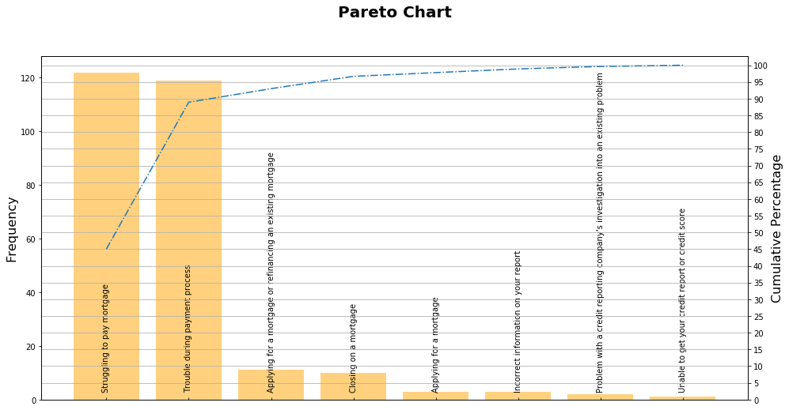

```python
%matplotlib inline

import matplotlib.pyplot as plt

def set_count_axis(count_axis, stats, column_name):
    count_axis.set_xticks(stats.index.values)
    count_axis.set_xticklabels(stats[column_name].values, rotation=90, va='bottom')
    count_axis.tick_params(axis="x",direction="in", pad=-10)
    count_axis.set_ylabel("Frequency", size=16)

def set_cumulative_percentage_axis(cumulative_percentage_axis):
    cumulative_percentage_axis.set_yticks(np.arange(0., 101., 5.))
    cumulative_percentage_axis.set_ylabel('Cumulative Percentage', size=16)

def create_bar_plot(count_axis, stats, column_name):
    count_axis.bar(stats.index.values, stats["count"].values, alpha = 0.5, color='orange')
    set_count_axis(count_axis, stats, column_name)


def create_line_plot(cumulative_percentage_axis, stats):
    cumulative_percentage_axis.plot(stats.index.values, stats.cummulative_percentage.values, linestyle="-.")
    set_cumulative_percentage_axis(cumulative_percentage_axis)

def pareto_chart(data, column_name):
    stats = get_pareto_stats(data, column_name)

    figure, count_axis = plt.subplots(figsize=(16, 8))
    create_bar_plot(count_axis, stats, column_name)

    cumulative_percentage_axis = count_axis.twinx()
    create_line_plot(cumulative_percentage_axis, stats)

    plt.title('Pareto Chart', fontweight="bold", fontsize=20, y=1.1)
    plt.grid()
    return figure

figure = pareto_chart(mortage_complaints, 'Issue')
figure.savefig('pareto-chart-1')
plt.show()
```

The code in this plot is reasonably general, so you may provide a different data frame and specify a different column name to have a Pareto chart built for it:

```
pareto_chart(<my data frame>, <my categorical column>)
```

That's all, folks! I hope you have learned a lot about the Pareto distribution.